# USA Home Sales

## 5. Prognosen

**Mit `STL()` funktion von `forecast` package:**

```r
########## mit stl benoetigt das Paket forecast ####################
##### mit stl, besser als decompose #############
real=ts(c(1973, 275), frequency = 12,
        start = c(1995,1))
par(mfrow=c(1,1))
dec.pass=stl(sales_ts_ohne_na, "per")
dec.pass
```

```
 Call:
 stl(x = sales_ts_ohne_na, s.window = "per")

Components
          seasonal    trend     remainder
Jan 1973 -7.052493 61.82257   0.229924553
Feb 1973 -1.230381 60.22258   1.007797644
Mar 1973 -1.230381 58.62260  10.607783268
Apr 1973 -1.230381 57.06243   7.167954891
May 1973 -1.230381 55.50225  10.728126513
Jun 1973 -1.230381 54.00072   8.229659946
Jul 1973 -1.230381 52.49919   2.731193379
Aug 1973 -1.230381 51.05776   2.172624177
Sep 1973 -1.230381 49.61633  -2.385945024
Oct 1973 -1.230382 48.47375  -5.243364787
Nov 1973 -1.230382 47.33117  -9.100784549
Dec 1973 -1.230382 46.71048 -15.480098727
Jan 1974 -1.230382 46.08979  -7.859412905
Feb 1974 -7.052493 45.68398   5.368513088
Mar 1974 -1.230381 45.27817  10.952215020
Apr 1974 -1.230381 44.83067   9.399713294
May 1974 -1.230381 44.38317  14.847211579
Jun 1974 -1.230381 43.73419   7.496194529
Jul 1974 -1.230381 43.08520   6.145177480
Aug 1974 -1.230381 42.27816   3.952222771
Sep 1974 -1.230381 41.47111   0.759268063
Oct 1974 -1.230381 40.95995  -5.729568248
Nov 1974 -1.230382 40.44879  -9.218404558
Dec 1974 -1.230382 40.52756 -15.297176051
Jan 1975 -1.230382 40.60633 -10.375947545
Feb 1975 -7.052493 41.25403  -0.201534597
Mar 1975 -1.230381 41.90173   3.328654211
Apr 1975 -1.230381 42.99659  12.233795016
May 1975 -1.230381 44.09145  14.138935831
Jun 1975 -1.230381 45.38910   6.841279047
Jul 1975 -1.230381 46.68676   5.543622263
Aug 1975 -1.230381 47.76362   6.466758666
Sep 1975 -1.230381 48.84049  -1.610104931
Oct 1975 -1.230381 49.39289  -2.162510337
Nov 1975 -1.230382 49.94530  -2.714915742
```

[output cut: 225 more lines]

```
Sep 1994 -1.230381 54.47325   0.757127815
Oct 1994 -1.230381 54.05382   4.176559377
Nov 1994 -1.230382 53.63439  -7.404009061
Dec 1994 -1.230382 53.80952 -12.579137363
Jan 1995 -1.230382 53.98465  -5.754265665
Feb 1995 -7.052493 54.40554  -0.353043748
Mar 1995 -1.230381 54.82643   6.403954028
Apr 1995 -1.230381 55.09259   4.137791239
May 1995 -1.230381 55.35875   8.871628459
Jun 1995 -1.230381 55.64907   9.581308573
Jul 1995 -1.230381 55.93939   9.290988686
Aug 1995 -1.230381 56.30171   7.928676013
Sep 1995 -1.230381 56.66402  -0.433636660
Oct 1995 -1.230381 57.05055  -1.820166184
Nov 1995 -1.230382 57.43708 -12.206695709
```

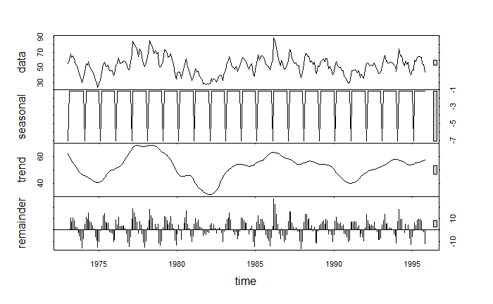

```r
plot(dec.pass)
```

```r
#plot daten und modell
plot(sales_ts_ohne_na, main="Passagierzahlen: saisonale Zerlegung mit stl", ylab="Passagierzahlen in 1000")
lines((dec.pass$time.series[,2]), col=4)
```

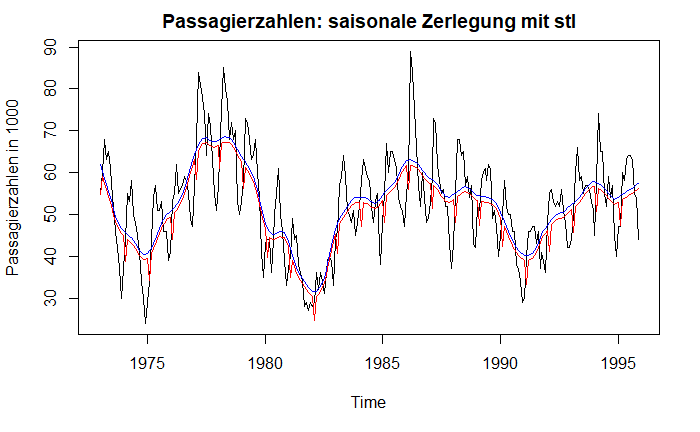

```r
lines((dec.pass$time.series[,2]+dec.pass$time.series[,1]), col=2)
```

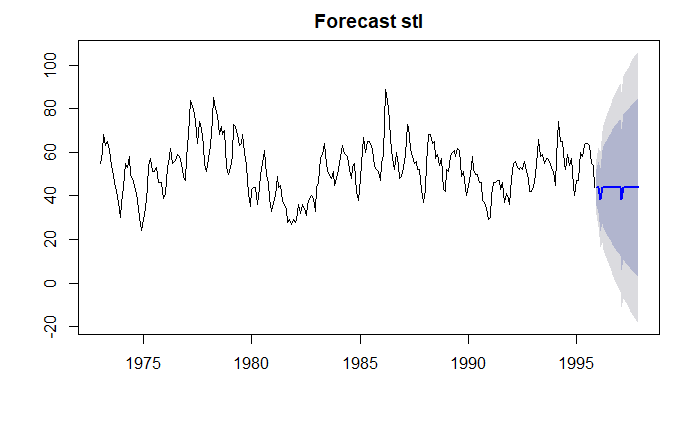

```r
plot(forecast(dec.pass), main="Forecast stl")
```

```r
plot(sales_ts_ohne_na, main="Monatlichen Sales: Vorhersage")
lines((forecast(dec.pass)$mean), col="green", lwd=2)
```

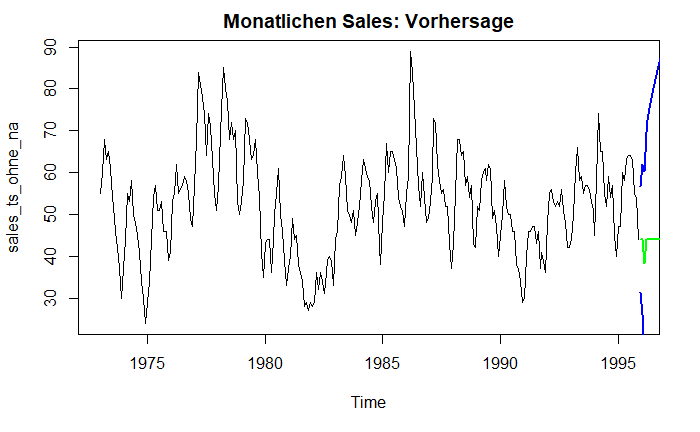

```r
lines((forecast(dec.pass)$lower[,2]), col="blue", lwd=2)
lines((forecast(dec.pass)$upper[,2]), col="blue", lwd=2)
```

```r
#lines(real, col=6, lwd=2)
```

**Mit `sarima.for()` from `astsa` package:**

> fit<-Arima(sales_ts_ohne_na,order = c(1,0,0),seasonal = c(1,0,0),include.drift = TRUE)

```
$`pred`
          Jan      Feb      Mar      Apr May Jun Jul Aug Sep Oct Nov      Dec
1995                                                                 45.19548
1996 46.21607 47.08735 47.83116 48.46616

$se
           Jan       Feb       Mar       Apr May Jun Jul Aug Sep Oct Nov       Dec
1995                                                                      6.163496
1996  8.104027  9.265719 10.027947 10.548826
```

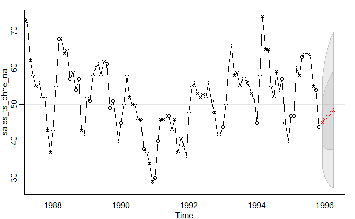

```r
sarima.for(sales_ts_ohne_na,5,1,0,0)
```

## 4. Vergleichen AR und Auto Arima Modelle

AR:

```r
summary(arima(sales_ts_ohne_na,order=c(21,0,0)))
```

```
Call:
arima(x = sales_ts_ohne_na, order = c(21, 0, 0))

Coefficients:
         ar1      ar2      ar3      ar4     ar5      ar6     ar7      ar8      ar9    ar10
      0.8732  -0.0292  -0.0822  -0.0605  0.1595  -0.0091  0.0212  -0.0602  -0.0313  0.2014
s.e.  0.0595   0.0782   0.0779   0.0775  0.0772   0.0777  0.0773   0.0773   0.0771  0.0754
         ar11    ar12     ar13    ar14     ar15    ar16    ar17     ar18    ar19     ar20    ar21
      -0.0372  0.2892  -0.1859  0.0155  -0.1311  0.0029  0.0658  -0.1585  0.1082  -0.2335  0.1507
s.e.   0.0763  0.0755   0.0775  0.0784   0.0784  0.0790  0.0790   0.0790  0.0796   0.0798  0.0611
      intercept
        52.6856
s.e.     2.1056

sigma^2 estimated as 21.02:  log likelihood = -812.66,  aic = 1671.31

Training set error measures:
                      ME     RMSE      MAE       MPE     MAPE      MASE        ACF1
Training set -0.03343723 4.585222 3.501625 -0.924734 6.979855 0.6907452 0.002623198
```

Auto ARIMA:

```r
summary(fit_auto_arima)
```

```
Series: sales_ts_ohne_na
ARIMA(1,0,0)(1,1,0)[12] with drift

Coefficients:
         ar1     sar1    drift
      0.8867  -0.4320  -0.0228
s.e.  0.0294   0.0569   0.1642

sigma^2 estimated as 27.92:  log likelihood=-811.38
AIC=1630.76   AICc=1630.92   BIC=1645.05

Training set error measures:
                     ME     RMSE      MAE        MPE     MAPE      MASE        ACF1
Training set 0.06977783 5.137588 3.982385 -0.4155256 7.894716 0.4835491 -0.03677202
```

Fazit: Gute der Modellen

- ME: Mean Error
- RMSE: root mean squared error (AR modelle)
- MAE: mean absolute error (AR modelle)
- MPE: mean percentage error
- MAPE: mean absolute percentage error (AR modelle)
- ACF1: first-order autocorrelation coefficient (ACF1)

WINNER: AR Modelle mit Ordnung 21.

> Cheers Cevi & Jabr